# Assesment1

Volodymyr Dovhanyk

Friday, August 14, 2015

# Loading and preprocessing the data

This markupfile is generated as resualts of peer assesment for week 2 at Coursera “Reproducible research” courses. Firstly we download th file with initial data into your working directory and read the data with R. **This code can produce some warnings but file should besuccesfully downloaded and precessed.**

```r
unzip (zipfile="activity.zip", exdir="data")
data<-read.csv("data/activity.csv")
```

# What is mean total number of steps taken per day?

```r
meanSteps<-aggregate(data$steps, by=list(data$date), FUN=mean)
```

In addition we can evaluate the mean values based on the histogram. *Please note NAs are replaced by 0*

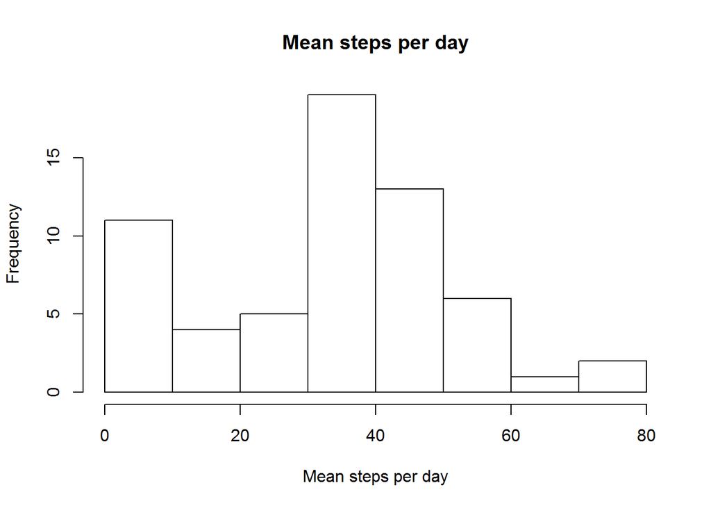

```r
meanSteps$x[is.na(meanSteps[2])]<-0
hist(as.numeric(meanSteps$x), xlab="Mean steps per day", main="Mean steps per day")
```

The mean of the total number of steps taken per day is equal 37.3825996 and median NA.

# What is the average daily activity pattern?

Average number of steps taken, averaged across all days is presented in the chart below

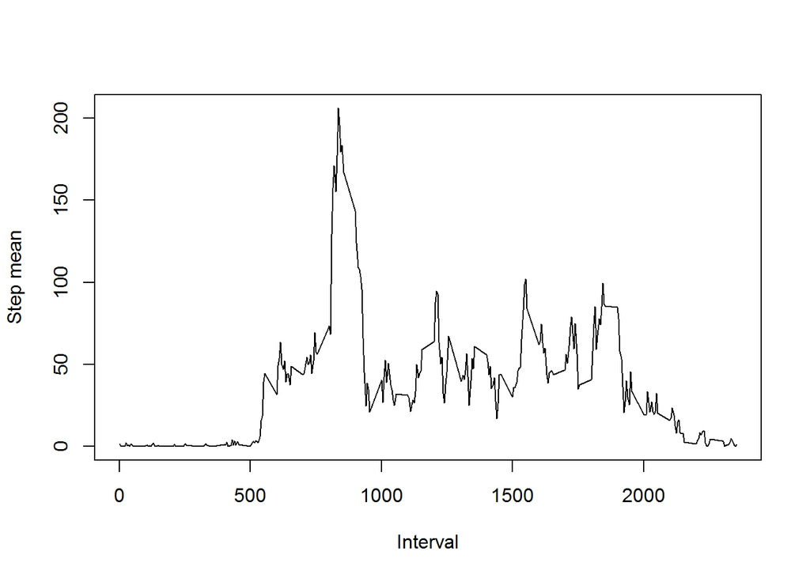

```r
meanStepsDayly<-aggregate(data$steps, by=list(data$interval), FUN=mean, na.rm=T)
plot(meanStepsDayly$Group.1, meanStepsDayly$x, type="l",
     xlab="Interval", ylab="Step mean")
```

Maximum number of steps os reached at 835 and reaches value 206.1698113 #Imputing missing values

Initial dataset contains 2304 NA values. To improve quality of dataset we create new dataset CleanData and replace NAs with mean values for the corresponding intervals.

```r
CleanData<-data
for (i in 1:length(CleanData$steps)) {
    if (is.na(CleanData$steps[i])) {
        CleanData$steps[i]<-
            meanStepsDayly$x[meanStepsDayly$Group.1==CleanData$interval[i]]
    }
}
```

Results of such kind repacement can be evaluated on the cart bellow.

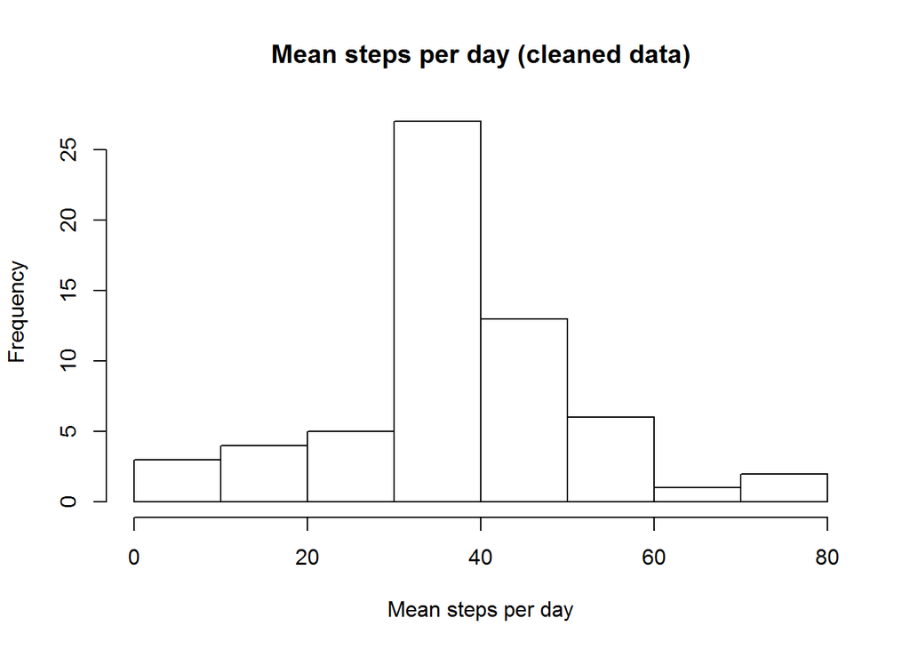

```r
NewMeanSteps<-aggregate(CleanData$steps, by=list(data$date), FUN=mean)
hist(as.numeric(NewMeanSteps$x), xlab="Mean steps per day", main="Mean steps per day (cleaned data)")
```

```r
NewMean<-mean(CleanData$steps)
NewMedian<-median(CleanData$steps)
```

# Are there differences in activity patterns between weekdays and weekends?

First of all we defined weekdays and append corresponding column to the cleaned dataset.

```r
weekdays<-factor(c("weekend","weekday"))
CleanData<-cbind(CleanData,weekdays)
weekend<-c("субота", "неділя")
weekday<-c("понеділок", "вівторок", "середа", "четвер", "п'ятниця")
CleanData$weekdays[weekdays(as.Date(CleanData$date)) %in% weekday]<-"weekday"
CleanData$weekdays[weekdays(as.Date(CleanData$date)) %in% weekend]<-"weekend"
```

Please notice for weekdays we use Ukranian names субота, неділя and понеділок, вівторок, середа, четвер, п’ятниця instead of English ones, because of using cyrylic settings in OS. We can evaluate the differences between weekdyas and weekends in the chart below.

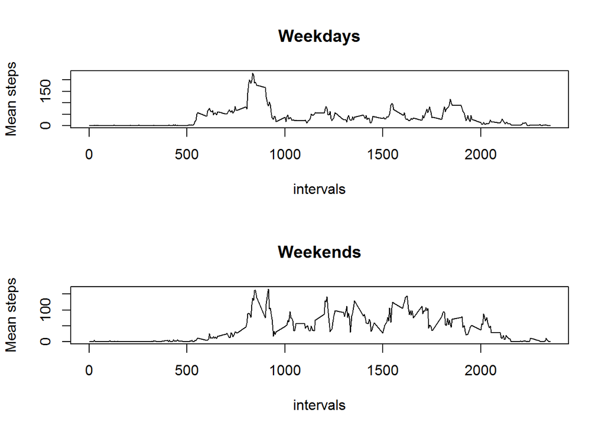

```r
meanStepsDaylyWD<-aggregate(CleanData$steps,
                            by=list(CleanData$interval, CleanData$weekdays), FUN=mean)

par(mfrow=c(2,1))

plot(x=meanStepsDaylyWD$Group.1[meanStepsDaylyWD$Group.2=="weekday"],
     y=meanStepsDaylyWD$x[meanStepsDaylyWD$Group.2=="weekday"], type="l",
     xlab="intervals", ylab="Mean steps", main="Weekdays")
plot(x=meanStepsDaylyWD$Group.1[meanStepsDaylyWD$Group.2=="weekend"],
     y=meanStepsDaylyWD$x[meanStepsDaylyWD$Group.2=="weekend"], type="l",
     xlab="intervals", ylab="Mean steps", main="Weekends")
```